# Analiza opinii klientów

Agnieszka Choczyńska

26 marca 2018

## Wstęp

Praca ma na celu analizę tekstu opinii klientów na temat produktów spożywczych w celu późniejszego przygotowania modelu, prognozującego punktową ocenę na podstawie recenzji.

Przeanalizowane zostaną różne właściwości tekstu:

```r
library(tidytext)
library(dplyr)
library(readr)
library(ggplot2)
library(stringr)
```

## Analiza

### Dane

Pierwszym krokiem jest wczytanie i wstępna obróbka danych:

```r
#Setting project directory
setwd("~/food-review-model")

#Loading dataset
reviews <- read_csv("food.csv")
reviews <- reviews %>%
  mutate(nr = row_number())
```

Zawierają one **28138** obserwacji, składających się z:

- zmiennej całkowitej **Score**, przedstawiającej liczbę punktów w skali **1 - 5**, jaką klient przyznał produktowi
- zmiennej tekstowej **Summary**, zawierającej krótkie podsumowanie recenzji
- zmiennej tekstowej **Text**, zawierającej pełny tekst recenzji
- dodatkowej zmiennej całkowitej **nr**, oznaczającej numer recenzji i służącej jako identyfikator

Fragment danych przedstawiono na wydruku poniżej.

```
## # A tibble: 6 x 4
##   Score Summary                               Text                      nr
##   <int> <chr>                                 <chr>                  <int>
## 1     2 Disappointing                         The rooibos is fine b~     1
## 2     5 Cavendar's Salt-Free                  This is a must-have f~     2
## 3     5 These bars are the best on the market I have been enjoying ~     3
## 4     5 Great tea and great value!            Good quality tea, and~     4
## 5     5 sweetner                              its a good sweetner i~     5
## 6     3 Low quality ingredients, but...       As the ingredients co~     6
```

Na wstępie warto jeszcze zwrócić uwagę na rozkład danych w zmiennej **Score**. Jak widać na załączonym poniżej histogramie, zdecydowana większość ocen produktów jest bardzo pozytywna (5 punktów), co będzie miało znaczenie przy doborze hipotez.

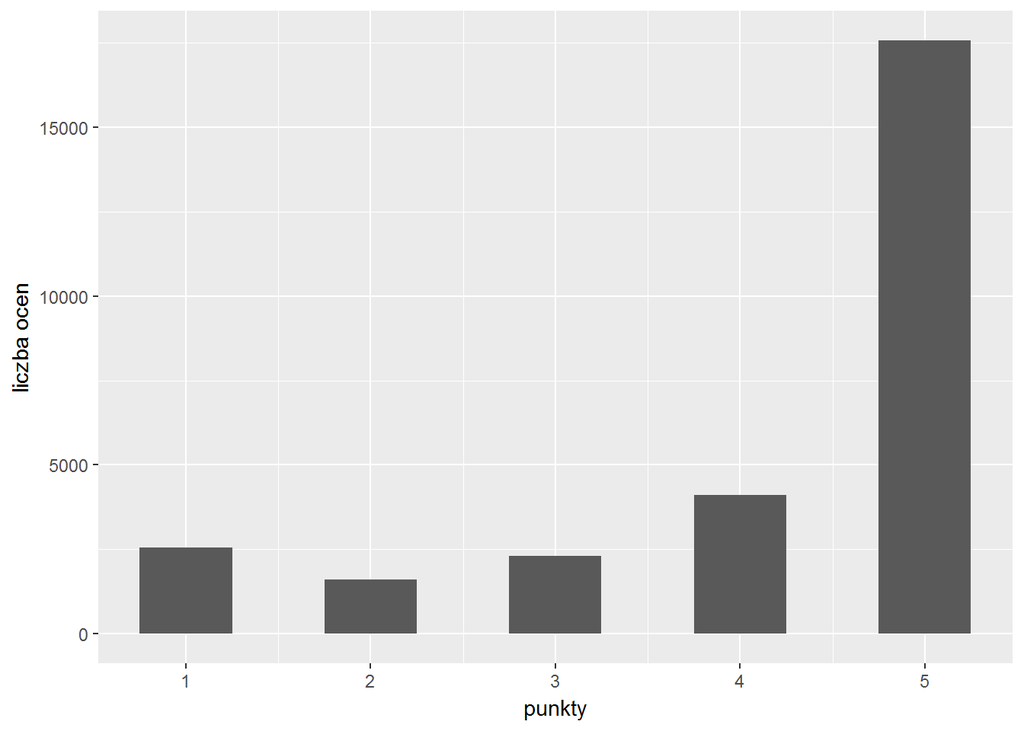

```r
ggplot(reviews) +
  geom_histogram(aes(x=Score), bins=9) +
  ylab("liczba ocen") +
  xlab("punkty")
```

W tej części pracy postawiono następujące hipotezy:

- **Im dłuższy tekst recenzji, tym więcej punktów zdobywa produkt.** Ponieważ niewiele jest w zbiorze ocen negatywnych, można się spodziewać, że większość recenzji będzie albo wyrażała entuzjazm (co wiąże się z kwiecistym językiem), albo obojętność (oszczędność w słowach)
- **Im więcej pozytywnych słów w recenzji, tym więcej punktów zdobywa produkt.**
- **Niewerbalne elementy tekstu mają odzwierciedlenie w ocenie.** Zbadano występowanie czterech takich elementów. Założono, że *wykrzykniki* wiążą się z bardziej pozytywnymi ocenami, *pytajniki* oraz *wielokropki* z bardziej negatywnymi (jako wyraz rozczarowania), a występowanie fragmentów wypisanych wielkimi literami również z negatywnymi (jako wyraz złości).

Zależności te zostały zbadane zarówno na tekście pełnej recenzji (zmienna `Text`) jak i krótkim podsumowaniu (zmienna `Summary`), ale ponieważ wyniki okazały się bardzo podobne, w pracy zamieszczono tylko analizę podsumowania, aby ograniczyć złożoność obliczeniową.

### Relacja między długością recenzji a oceną

Sprawdzenie tej hipotezy odbywa się poprzez proste zliczenie słów w podsumowaniach recenzji, a następnie zestawienie długości tekstu i liczby uzyskanych przez produkt punktów na wykresie.

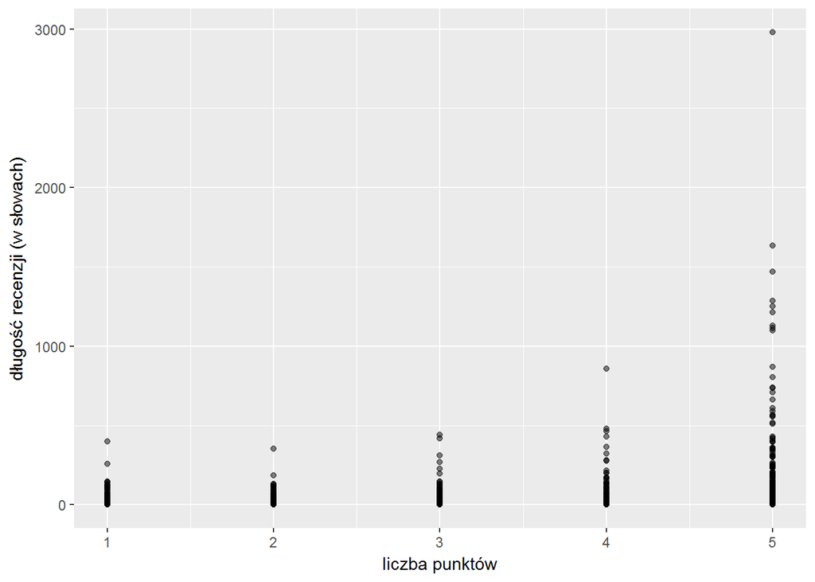

```r
#Analizing words in Text
descWords <- reviews %>%
  select(nr, Summary) %>%
  unnest_tokens(word, Summary)

descWords %>% left_join(reviews) %>%
  count(Score, word) %>%
  ggplot(aes(x=Score, y=n)) +
  geom_point(alpha = .5) +
  xlab("liczba punktów") +
  ylab("długość recenzji (w słowach)")
```

Chociaż widać, że produkty wycenione na 5 punktów mają sporo długich recenzji, nie wydaje się, by faktycznie liczba słów mogła mieć duży wpływ na ocenę.

### Relacja między pozytywnym/negatywnym zabarwieniem słów a oceną

Ta część analizy zostanie przeprowadzona z wykorzystaniem słownika *afinn*, oznaczającego nacechowane wartościująco słowa liczbami całkowitymi w skali od **-5** (bardzo negatywne) do **5** (bardzo pozytywne).

```r
#lexicon
#(-5 - very negative, 5 - very positive)
afinn <- get_sentiments("afinn")
```

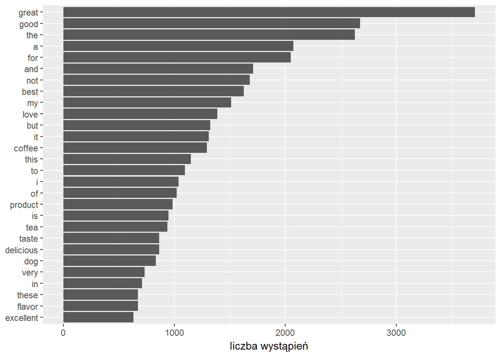

```r
#Structure
descWords %>%
  count(word, sort = T) %>%
  filter(n > 600) %>%
  mutate(word = reorder(word, n)) %>%
  ggplot(aes(x = word, y = n)) +
  geom_col() +
  xlab(NULL) +
  ylab("liczba wystąpień") +
  coord_flip()
```

Przedstawione powyżej oparacje są wykonywane przez następujący kod:

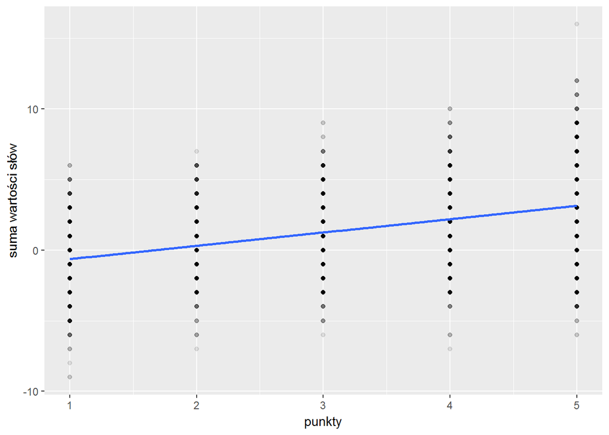

```r
#Including the impact of word "not" or "don't"
descWords <- descWords %>%
  mutate(not = ifelse(lag(word, n=1) == "not", -1, 1))

descSentiment <- descWords %>% inner_join(afinn) %>%
  rename(sentiment = score) %>%
  group_by(nr) %>%
  summarise(sum = sum(sentiment*not))

descSentiment %>% left_join(reviews) %>%
  ggplot(aes(x=Score, y=sum)) +
  geom_point(alpha = .1) +
  geom_smooth(method="lm") +
  ylab("suma wartości słów") +
  xlab("punkty")
```

Wykres pokazuje wyraźną, spodziewaną zależność między oceną produktu a sumą wartości słów w recenzji, jednak widać też, że rozrzut wyników jest bardzo duży.

### Relacja między pozawerbalnymi elementami tekstu a oceną

W celu sprawdzenia hipotez związanych z występowaniem określonych znaków interpunkcyjnych i fragmentów napisanych wielkimi literami posłużono się pakietem *stringr* i wyrażeniami regularnymi. Poniższy kod sprawdza, w których podsumowaniach występują dane elementy.

```r
#Punctuation
descPunct <- reviews %>%
  mutate(excl = str_detect(Summary, pattern="[!]"),
         quest = str_detect(Summary, pattern="[?]"),
         ellip = str_detect(Summary, pattern="[.]{3}"),
         cap = str_detect(Summary, pattern = "[:upper:]{2,}"))

exclR <- descPunct %>% group_by(excl) %>%
  summarise(mean = mean(Score))

questR <- descPunct %>% group_by(quest) %>%
  summarise(mean = mean(Score))

ellipR <- descPunct %>% group_by(ellip) %>%
  summarise(mean = mean(Score))

capR <- descPunct %>% group_by(cap) %>%
  summarise(mean = mean(Score))

result <- data.frame(exclR, questR, ellipR, capR)

print(result)
```

```
##    excl     mean quest   mean.1 ellip   mean.2   cap   mean.3
## 1 FALSE 4.045705 FALSE 4.175705 FALSE 4.174887 FALSE 4.171301
## 2  TRUE 4.499200  TRUE 3.041841  TRUE 3.699634  TRUE 4.001221
```

## Podsumowanie

Założone na początku analizy hipotezy wydają się znajdować potwierdzenie w danych. Żadna z badanych właściwości tekstu nie wiąże się jednak w bardzo wyraźny sposób z uzyskaną przez produkt oceną.